# My visual data story

## Introduction

Instagram advertisements are heavily personalised and designed to capture user attention.

This project investigates the types of advertisements that appeared most frequently during Instagram browsing, the times of day when advertisements were most engaging, and how interest levels varied across advertisement categories.

[figure not shown]

Clothing advertisements appeared most frequently within the dataset, suggesting that Instagram’s advertising algorithm strongly prioritised fashion-related content.

## Average Interest by Time of Day

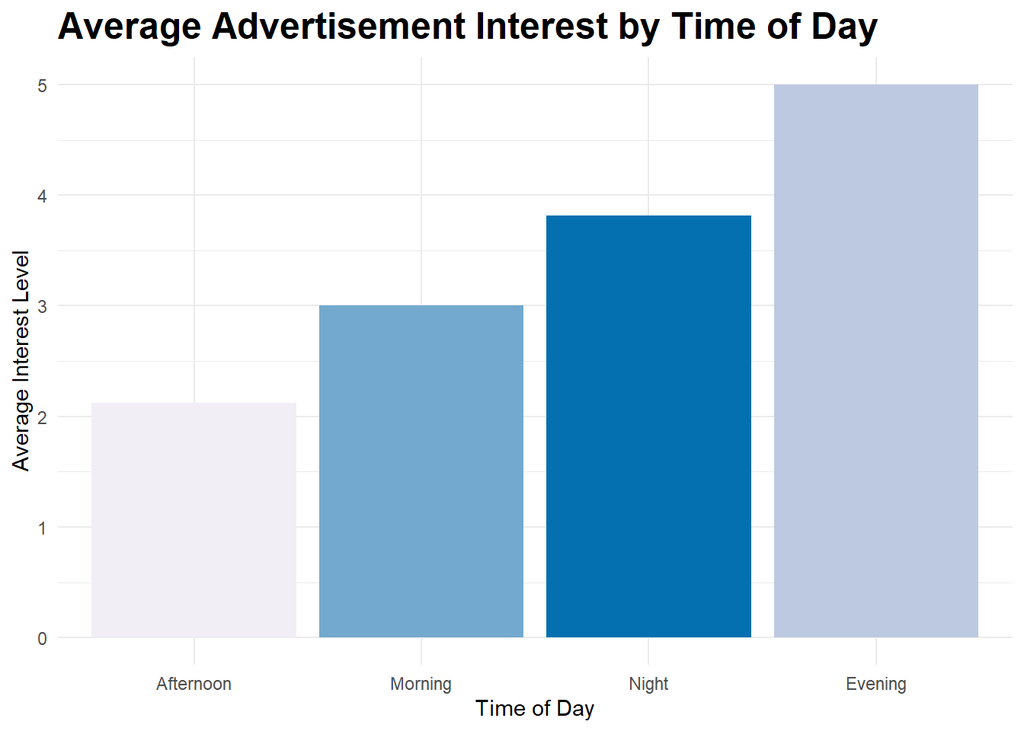

Average interest levels varied across different observation periods. Advertisements viewed during the evening generally received higher interest scores than advertisements viewed earlier in the day.

## Interest Levels Across Advertisement Categories

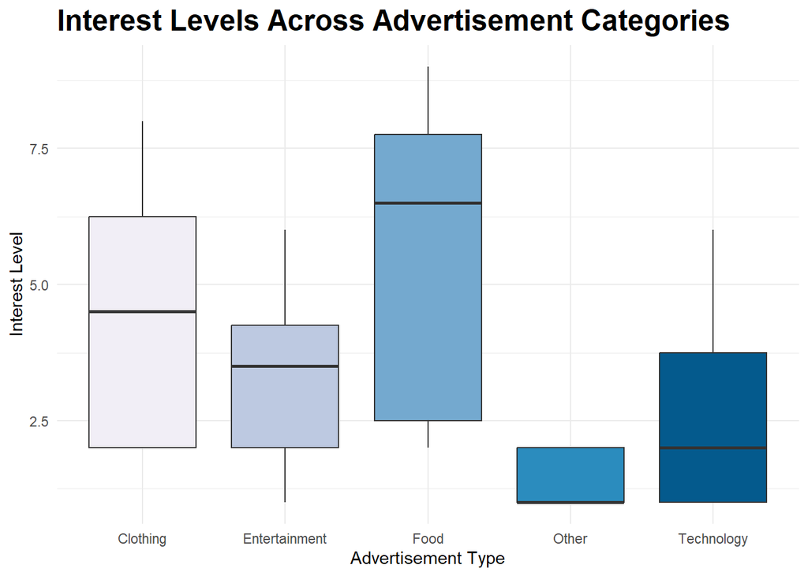

Different advertisement categories produced different levels of engagement. Some categories consistently received low interest scores, while others showed greater variation and occasionally high engagement levels.

## Conclusion

This project explored how Instagram advertisements vary across categories and observation periods.

The visualisations suggest that advertisement engagement is influenced by both advertisement type and browsing context. The analysis also demonstrates how personalised advertising systems attempt to maximise user attention through repeated exposure to specific categories of content.